# Advanced statistical analysis of biomechanical time series: PCA, FDA and SPM

This workshop was held on 6 July 2018 at Trinity College, Dublin. This Jupyter notebook is distributed with the workshop documents and directed at users who may desire more details than are provided in the **MATLAB** scripts, also distributed with the workshop material:

- FDA_fPCA_Example.m
- FDA_T_Test_Example.m
- SPM_T_Test_Example.m
- SnPM_T_Test_Example.m

Data for this World Congress of Biomechanics (WCB) 2018 workshop are from:

Warmenhoven, J. S., Harrison, A., Robinson, M., Vanrenterghem, J., Bargary, N., Smith, R., Cobley, S., Draper, C., Donnelly, C., & Pataky, T. (2018). A force profile analysis comparison between functional data analysis, statistical parametric mapping and statistical non-parametric mapping in on-water single sculling. Journal of Science & Medicine in Sport, In Press. https://www.jsams.org/article/S1440-2440(18)30091-4/abstract

For any questions related to this workshop, scripts or this notebook, please email: john.warmenhoven@hotmail.com

## Step 1: Set MATLAB path

In order to use the **spm1d** and **fda** software packages you need to first set the MATLAB path so that MATLAB knows where to find these packages' functions. If you are using Windows and you copied the required packages and dataset to the following locations:

- C:\Temp\fdaM
- C:\Temp\spm1dmatlab
- C:\Temp\Simulated_Data.mat

Then you can set the path in MATLAB's Command Window using the following commands:

```matlab
addpath('C:\Temp\fdaM')  %path to fda
addpath(genpath('C:\Temp\spm1dmatlab'))   %path to spm1d
addpath('C:\Temp')  %path to the folder in which the data file has been saved
```

To test that you have set the paths correctly for **fda**, enter the following command:

```matlab
create_bspline_basis([0,100], 51, 6);
```

To test that you have set the paths correctly for **spm1d**, enter the following command:

```matlab
spm1d.stats.ttest( randn(8,1) );
```

To test that you have set the paths correctly for the dataset, enter the following command:

```matlab
load('Simulated_Data')
```

If all three of these commands run without errors then the paths have been correctly set.

## Step 2: Load data

Next load and visualize the data.

```matlab
load('Simulated_Data')
```

This will load four variables into the **MATLAB** workspace, as listed in the Workspace window.

[figure not shown]

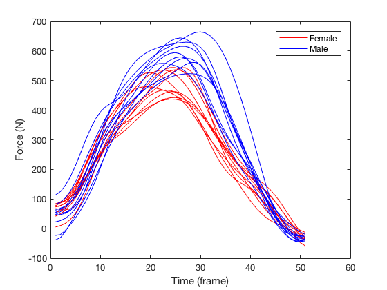

```matlab
h0 = plot(Pin_Force_Bow_Female, 'r');
hold on
h1 = plot(Pin_Force_Bow_Male, 'b');
legend([h0(1) h1(1)], 'Female', 'Male')
xlabel('Time (frame)')
ylabel('Force (N)')
```

The means and standard deviations (SDs) can be computed and plotted like this:

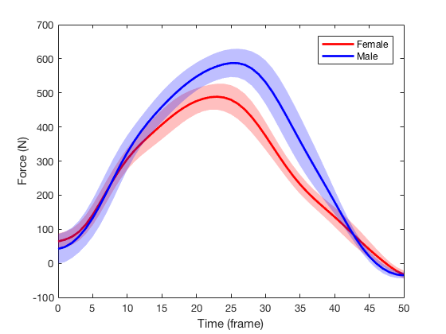

```matlab
h0 = spm1d.plot.plot_meanSD(Pin_Force_Bow_Female', 'color','r');
hold on
h1 = spm1d.plot.plot_meanSD(Pin_Force_Bow_Male', 'color','b');
legend([h0 h1], 'Female', 'Male')
xlabel('Time (frame)')
ylabel('Force (N)')
```

## SPM t test example

The data can be loaded below and for the purposes of this exemplar script, has been labelled "Simulated_Data."

```matlab
addpath(genpath('/Users/todd/WorkingCopies/spm1dmatlab/trunk'))
load('/Users/todd/Desktop/Simulated_Data.mat');
```

This is a parametric t-test, and the **spm1d.stats.ttest2** and **inference** functions are described comprehensively at spm1d.org and within the functions as well. This t-test is for the bow-side data and alpha is set at 0.05.

```matlab
spm  = spm1d.stats.ttest2(Pin_Force_Bow_Male', Pin_Force_Bow_Female');
spmi = spm.inference(0.05, 'two_tailed', true);
```

The **plot** methods of the spmi variable allow for visualization of the results of the t-test for the bow-side of the boat.

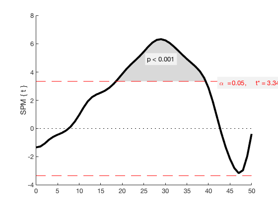

```matlab
spmi.plot();
spmi.plot_threshold_label();
spmi.plot_p_values();
```